# B50_Drawing_a_Qubit

| Abuzer Yakaryilmaz \| April 12, 2019 (updated) |
| --- |
| This cell contains some macros. If there is a problem with displaying mathematical formulas, please run this cell to load these macros. |

$ \newcommand{\bra}[1]{\langle #1|} $ $ \newcommand{\ket}[1]{|#1\rangle} $ $ \newcommand{\braket}[2]{\langle #1|#2\rangle} $ $ \newcommand{\dot}[2]{ #1 \cdot #2} $ $ \newcommand{\biginner}[2]{\left\langle #1,#2\right\rangle} $ $ \newcommand{\mymatrix}[2]{\left( \begin{array}{#1} #2\end{array} \right)} $ $ \newcommand{\myvector}[1]{\mymatrix{c}{#1}} $ $ \newcommand{\myrvector}[1]{\mymatrix{r}{#1}} $ $ \newcommand{\mypar}[1]{\left( #1 \right)} $ $ \newcommand{\mybigpar}[1]{ \Big( #1 \Big)} $ $ \newcommand{\sqrttwo}{\frac{1}{\sqrt{2}}} $ $ \newcommand{\dsqrttwo}{\dfrac{1}{\sqrt{2}}} $ $ \newcommand{\onehalf}{\frac{1}{2}} $ $ \newcommand{\donehalf}{\dfrac{1}{2}} $ $ \newcommand{\hadamard}{ \mymatrix{rr}{ \sqrttwo & \sqrttwo \\ \sqrttwo & -\sqrttwo }} $ $ \newcommand{\vzero}{\myvector{1\\0}} $ $ \newcommand{\vone}{\myvector{0\\1}} $ $ \newcommand{\vhadamardzero}{\myvector{ \sqrttwo \\ \sqrttwo } } $ $ \newcommand{\vhadamardone}{ \myrvector{ \sqrttwo \\ -\sqrttwo } } $ $ \newcommand{\myarray}[2]{ \begin{array}{#1}#2\end{array}} $ $ \newcommand{\X}{ \mymatrix{cc}{0 & 1 \\ 1 & 0} } $ $ \newcommand{\Z}{ \mymatrix{rr}{1 & 0 \\ 0 & -1} } $ $ \newcommand{\Htwo}{ \mymatrix{rrrr}{ \frac{1}{2} & \frac{1}{2} & \frac{1}{2} & \frac{1}{2} \\ \frac{1}{2} & -\frac{1}{2} & \frac{1}{2} & -\frac{1}{2} \\ \frac{1}{2} & \frac{1}{2} & -\frac{1}{2} & -\frac{1}{2} \\ \frac{1}{2} & -\frac{1}{2} & -\frac{1}{2} & \frac{1}{2} } } $ $ \newcommand{\CNOT}{ \mymatrix{cccc}{1 & 0 & 0 & 0 \\ 0 & 1 & 0 & 0 \\ 0 & 0 & 0 & 1 \\ 0 & 0 & 1 & 0} } $ $ \newcommand{\norm}[1]{ \left\lVert #1 \right\rVert } $

## Drawing a Qubit

| *We use certain tools from python library "**matplotlib.pyplot**" for drawing. Check the notebook "Python: Drawing" for the list of these tools.* |
| --- |

Suppose that we have a single qubit.

Each possible (real-valued) quantum state of this qubit is a point on 2-dimensional space.

It can also be represented as a vector from origin to that point.

We start with the visual representation of the following quantum states:

$$ \ket{0} = \myvector{1\\0}, ~~ \ket{1} = \myvector{0\\1} , ~~ -\ket{0} = \myrvector{-1\\0}, ~~\mbox{and}~~ -\ket{1} = \myrvector{0\\-1}. $$

We first draw these quantum states as points.

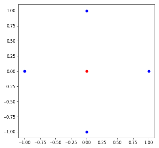

```python
# import the drawing methods
from matplotlib.pyplot import plot, figure

# draw a figure
figure(figsize=(6,6), dpi=60)

# draw the origin
plot(0,0,'ro') # a point in red color

# draw the quantum states as points (in blue color)
plot(1,0,'bo')
plot(0,1,'bo')
plot(-1,0,'bo')
plot(0,-1,'bo')
```

Then, we draw the points and the axes together.

We have a predefined function for drawing axes: "draw_axes()".

We include our predefined functions with the following line of code:

```
%run qlatvia.py
```

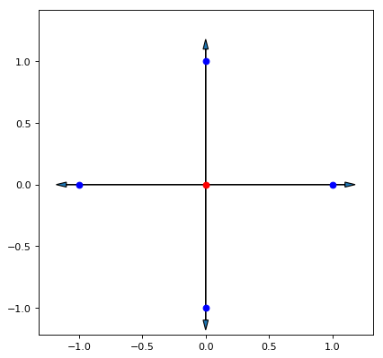

```python
# import the drawing methods
from matplotlib.pyplot import plot, figure

# draw a figure
figure(figsize=(6,6), dpi=80)

# include our predefined functions
%run qlatvia.py

# draw the axes
draw_axes()

# draw the origin
plot(0,0,'ro') # a point in red color

# draw these quantum states as points (in blue color)
plot(1,0,'bo')
plot(0,1,'bo')
plot(-1,0,'bo')
plot(0,-1,'bo')
```

Now, we draw the quantum states as vectors by also showing axes:

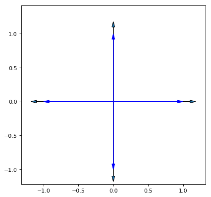

```python
# import the drawing methods
from matplotlib.pyplot import figure, arrow

# draw a figure
figure(figsize=(6,6), dpi=80)

# include our predefined functions
%run qlatvia.py

# draw the axes
draw_axes()

# draw the quantum states as vectors (in blue color)
arrow(0,0,0.92,0,head_width=0.04, head_length=0.08, color="blue")
arrow(0,0,0,0.92,head_width=0.04, head_length=0.08, color="blue")
arrow(0,0,-0.92,0,head_width=0.04, head_length=0.08, color="blue")
arrow(0,0,0,-0.92,head_width=0.04, head_length=0.08, color="blue")
```

### Task 1

Write a function that returns a randomly created 2-dimensional (real-valued) quantum state.

| *You may use your code written for a task given in notebook "Quantum States".* |
| --- |

Create 100 random quantum states by using your function, and then draw all of them as points.

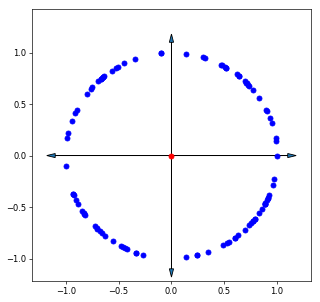

```python
# import the drawing methods
from matplotlib.pyplot import plot, figure

# draw a figure
figure(figsize=(6,6), dpi=60)

# draw the origin
plot(0,0,'ro')

# draw the axes
draw_axes()
#
# your solution is here
#
# include our predefined functions
%run qlatvia.py

for i in range(100):
    quantum_state = random_quantum_state()
    x = quantum_state[0];
    y = quantum_state[1];
    plot(x,y,'bo')
```

click for our solution

### Task 2

Repeat the previous task by drawing the quantum states as vectors (arrows) instead of points.

*Please keep the codes below for drawing axes for getting a better visual focus.*

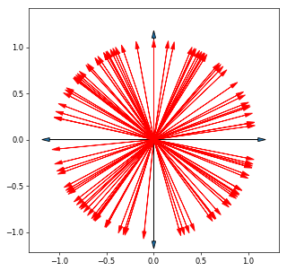

```python
# import the drawing methods
from matplotlib.pyplot import plot, figure, arrow

# draw a figure
figure(figsize=(6,6), dpi=60)

# include our predefined functions
%run qlatvia.py

# draw the axes
draw_axes()

# draw the origin
plot(0,0,'ro')

#
# your solution is here
#
for i in range(100):
    quantum_state = random_quantum_state()
    x = quantum_state[0];
    y = quantum_state[1];
    arrow(0,0,x,y,head_width=0.04,head_length=0.08,color="red")
```

click for our solution

### Unit circle

All quantum states of a qubit form the unit circle.

The length of each quantum state is 1.

All points that are 1 unit away from the origin form the circle with radius 1 unit.

We can draw the unit circle with python.

We have a predefined function for drawing the unit circle: "draw_unit_circle()".

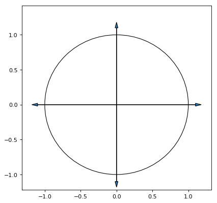

```python
# import the drawing methods
from matplotlib.pyplot import figure

figure(figsize=(6,6), dpi=80) # size of the figure

# include our predefined functions
%run qlatvia.py

# draw axes
draw_axes()

# draw the unit circle
draw_unit_circle()
```

We can place texts on 2-dimensional plane by using method

```
text(x,y,string)
```

We randomly place 5 strings on the plane.

```
1. point at (0.15,-0.4)
2. point at (-0.12,-0.7)
3. point at (-0.23,0.27)
4. point at (0.41,0.17)
5. point at (-0.23,0.21)
```

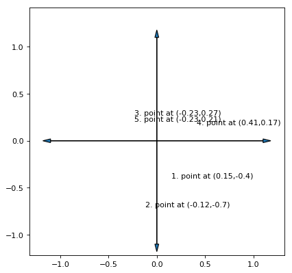

```python
# import the drawing methods
from matplotlib.pyplot import figure, text

figure(figsize=(6,6), dpi=80) # size of the figure

# include our predefined functions
%run qlatvia.py

# draw axes
draw_axes()

# randomly determine the points
from random import randrange
for i in range(5):
    x = randrange(-100,101)/100
    y = randrange(-100,101)/100
    string = str(i+1)+". point at ("+str(x)+","+str(y)+")"
    print(string)
    text(x,y,string)
```

### Task 3

Write a function that displays a quantum state with a name.

The parameters of the function should be (x,y,name).

Randomly pick a quantum state and display it with the axes and the unit circle.

The arrow head should be on the unit circle.

The name of the quantum state should be displayed out of the unit circle.

Test your function with 6 random quantum states.

Save your function for later usage.

```python
# %%writefile FILENAME.py
# import the drawing methods
from matplotlib.pyplot import figure, arrow, text

def display_quantum_state(x,y,name):
    # draw axes
    draw_axes()

    # draw the unit circle
    draw_unit_circle()

    # get the random quantum state
    quantum_state = random_quantum_state()
    x = quantum_state[0];
    y = quantum_state[1];
    arrow(0,0,x * 0.90,y * 0.90,head_width=0.04,head_length=0.1,color="red")

    # display the name out of unit circle
    text(x + 0.1,y + 0.1,name,fontsize=15)
```

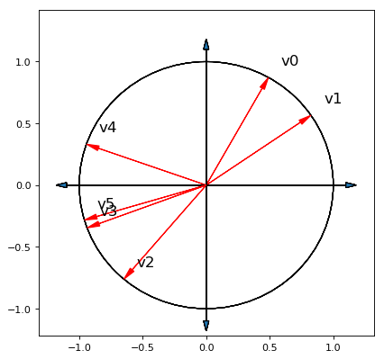

```python
#
# test your function
#

# import the drawing methods
from matplotlib.pyplot import figure

figure(figsize=(6,6), dpi=80) # size of the figure

# include our predefined functions
%run qlatvia.py

# draw axes
draw_axes()

# draw the unit circle
draw_unit_circle()

for i in range(6):
    s = random_quantum_state()
    display_quantum_state(s[0],s[1],"v"+str(i))
```

click for our solution